# Evaluación curso R

BELÉN FERNÁNDEZ REQUENA

## Entrega

- Recuerda completar tu **nombre en el apartado author**.
- Además del código, no olvides completar las respuestas a las preguntas indicadas en negrita.
- Si tienes dudas/dificultades, **puedes contactar con los profesores**.
- Deadline: **viernes 10 de junio, 23:59**.
- Puedes realizar la entrega en el mail: **constantino.garciama@ceu.es**.
- La entrega consistirá en este fichero rellenado y el fichero que se genera al hacer `Knit` (un fichero `Rmd` y un fichero `html`).

## Apuestas de adolescentes en UK

El conjunto de datos `teengamb.csv` contiene datos sobre las tasas de juego entre los adolescentes en Gran Bretaña, su género y estatus socioeconómico. Una pregunta que nos puede interesar es cómo se relacionan el género y los ingresos con cuánto juega una persona (céntrate solo en las variables `income`, `sex` y `gamble`)… Sigue los siguientes pasos para crear un ANCOVA…

### 1) Carga y visualiza los datos…

…para valorar si el modelo debe incluir interacciones. Escribe claramente tus conclusiones

```r
teengamb <- read.csv("teengamb.csv") #leer el documento
head (teengamb)
```

```
##      sex status income verbal     gamble
## 1 Female     51   2.00      8  20.965805
## 2 Female     28   2.50      8 -11.091514
## 3 Female     37   2.00      6  -8.586763
## 4 Female     28   7.00      4  17.351732
## 5 Female     65   2.00      8 -17.252409
## 6 Female     61   3.47      6  14.878533
```

```r
teengamb<-teengamb[,c(-2,-4)] # quitar las columnas de las variables que no sirven
head(teengamb)
```

```
##      sex income     gamble
## 1 Female   2.00  20.965805
## 2 Female   2.50 -11.091514
## 3 Female   2.00  -8.586763
## 4 Female   7.00  17.351732
## 5 Female   2.00 -17.252409
## 6 Female   3.47  14.878533
```

```r
table(teengamb$sex)
```

```
##
## Female   Male
##     19     28
```

```r
summary(teengamb) #mostrar información de los datos
```

```
##      sex                income           gamble
##  Length:47          Min.   : 0.600   Min.   :-33.5960
##  Class :character   1st Qu.: 2.000   1st Qu.: -0.8695
##  Mode  :character   Median : 3.250   Median : 17.7230
##                     Mean   : 4.642   Mean   : 21.4473
##                     3rd Qu.: 6.210   3rd Qu.: 35.0519
##                     Max.   :15.000   Max.   : 88.4473
```

```r
library("tidyverse")
```

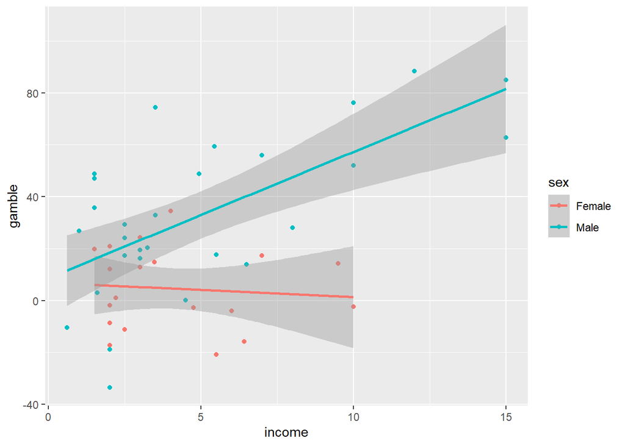

```r
teengamb = teengamb %>%
  mutate(sex = factor(sex)) # la variable sex es un character y hay que convertirla en un factor

ggplot(teengamb, aes(x = income, y = gamble, col = sex)) +
  geom_point() +
  geom_smooth(method="lm") #visualización de los datos
```

**Conclusiones sobre la necesidad de interacción**:

La visualización de los datos permite ver una interacción entre las variables income y sex, de manera que a priori podríamos establecer que existe una relación entre los ingresos de los individuos en función del sexo con cuánto juega una persona. Esto debemos comprobarlo en los siguientes apartados.

También debemos destacar que el grupo de los hombres muestra una pendiente ascendente mucho mayor que en el caso de las mujeres, de manera que, parece ser que a mayores ingresos, mayor es la frecuencia de juego en este grupo. Esta tendencia no se observa igual en el grupo de las mujeres.

### 2) Crea el modelo…

… y obtén:

- los intervalos de confianza para los coeficientes y su significación.
- Obtén los tamaños de los efectos.

```r
teengamb_lm = lm(gamble ~ sex * income, teengamb) #el modelo lineal
summary(teengamb_lm) #para hacer inferencia
```

```
##
## Call:
## lm(formula = gamble ~ sex * income, data = teengamb)
##
## Residuals:
##     Min      1Q  Median      3Q     Max
## -52.025 -15.479  -3.559  14.022  48.625
##
## Coefficients:
##                Estimate Std. Error t value Pr(>|t|)
## (Intercept)      6.8743     9.2446   0.744   0.4612
## sexMale          1.8427    11.1946   0.165   0.8700
## income          -0.5489     1.9024  -0.289   0.7743
## sexMale:income   5.4050     2.1435   2.522   0.0155 *
## ---
## Signif. codes:  0 '***' 0.001 '**' 0.01 '*' 0.05 '.' 0.1 ' ' 1
##
## Residual standard error: 20.97 on 43 degrees of freedom
## Multiple R-squared:  0.5105, Adjusted R-squared:  0.4764
## F-statistic: 14.95 on 3 and 43 DF,  p-value: 8.279e-07
```

```r
library("emmeans")
emmeans(teengamb_lm, ~ income | sex) #para ver los intervalos de confianza y comparar diferencias entre las medidas ajustadas
```

```
## sex = Female:
##  income emmean   SE df lower.CL upper.CL
##    4.64   4.33 4.90 43    -5.56     14.2
##
## sex = Male:
##  income emmean   SE df lower.CL upper.CL
##    4.64  31.26 3.98 43    23.24     39.3
##
## Confidence level used: 0.95
```

```r
library(car) #para cargar ANOVA
options(contrasts = c("contr.sum", "contr.poly"))
teengamb_aov = Anova(teengamb_lm, type=3) #ANOVA
print(teengamb_aov)
```

```
## Anova Table (Type III tests)
##
## Response: gamble
##              Sum Sq Df F value  Pr(>F)
## (Intercept)   243.2  1  0.5530 0.46116
## sex            11.9  1  0.0271 0.87003
## income         36.6  1  0.0832 0.77434
## sex:income   2796.4  1  6.3585 0.01547 *
## Residuals   18910.9 43
## ---
## Signif. codes:  0 '***' 0.001 '**' 0.01 '*' 0.05 '.' 0.1 ' ' 1
```

```r
library(effectsize)
eta_squared(teengamb_aov) #calcular el tamaño de efecto
```

```
## Type 3 ANOVAs only give sensible and informative results when covariates are
##   mean-centered and factors are coded with orthogonal contrasts (such as those
##   produced by 'contr.sum', 'contr.poly', or 'contr.helmert', but *not* by the
##   default 'contr.treatment').
```

```
## # Effect Size for ANOVA (Type III)
##
## Parameter  | Eta2 (partial) |       95% CI
## ------------------------------------------
## sex        |       6.30e-04 | [0.00, 1.00]
## income     |       1.93e-03 | [0.00, 1.00]
## sex:income |           0.13 | [0.01, 1.00]
##
## - One-sided CIs: upper bound fixed at (1).
```

### 3) Interpreta los coeficientes y escribe tus conclusiones.

**Conclusiones sobre las variables de interés**: los resultados mostrados de nuestro modelo y del test ANOVA demuestran que efectivamente hay una interacción significativa (0.0155) entre las variables income y sex. Al comprobar el intervalo de confianza del grupo de las mujeres, podemos ver que esté pasa por el 0, de manera que este no presenta diferencias significativas en sus datos. Sin embargo, en el grupo de los hombres, el intervalo de confianza no incluye el 0, por lo que los datos de este grupo sí que presentan diferencias significativas. Esto se asemeja a la asumciones que se han establecido en las conclusiones del punto 1.

### 4) Crea un gráfico con las predicciones de tu modelo…

…y compáralas con los datos reales.

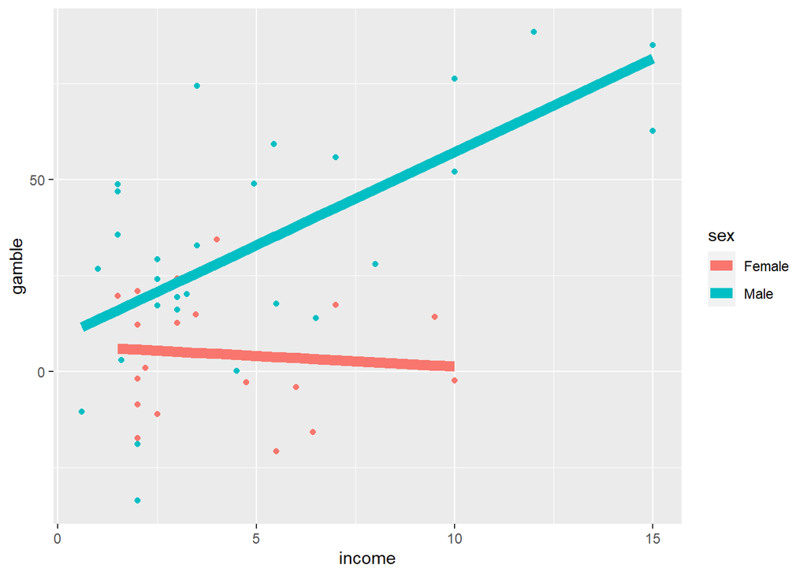

```r
tg_preds = teengamb %>% mutate(fit = predict(teengamb_lm))# predicciones del modelo
ggplot(tg_preds, aes(x = income, col=sex)) +
  geom_point(aes(y = gamble)) +
  geom_line(aes(y = fit), lwd = 3) #representar el ajuste del modelo
```

```r
summary(teengamb_lm)
```

```
##
## Call:
## lm(formula = gamble ~ sex * income, data = teengamb)
##
## Residuals:
##     Min      1Q  Median      3Q     Max
## -52.025 -15.479  -3.559  14.022  48.625
##
## Coefficients:
##                Estimate Std. Error t value Pr(>|t|)
## (Intercept)      6.8743     9.2446   0.744   0.4612
## sexMale          1.8427    11.1946   0.165   0.8700
## income          -0.5489     1.9024  -0.289   0.7743
## sexMale:income   5.4050     2.1435   2.522   0.0155 *
## ---
## Signif. codes:  0 '***' 0.001 '**' 0.01 '*' 0.05 '.' 0.1 ' ' 1
##
## Residual standard error: 20.97 on 43 degrees of freedom
## Multiple R-squared:  0.5105, Adjusted R-squared:  0.4764
## F-statistic: 14.95 on 3 and 43 DF,  p-value: 8.279e-07
```

**¿Es bueno el ajuste?:** El ajuste es bueno ya que el modelo se asemeja a las predicciones establecidas al comienzo del ejercicio.

### 5) Valora si las asunciones del modelo se cumplen

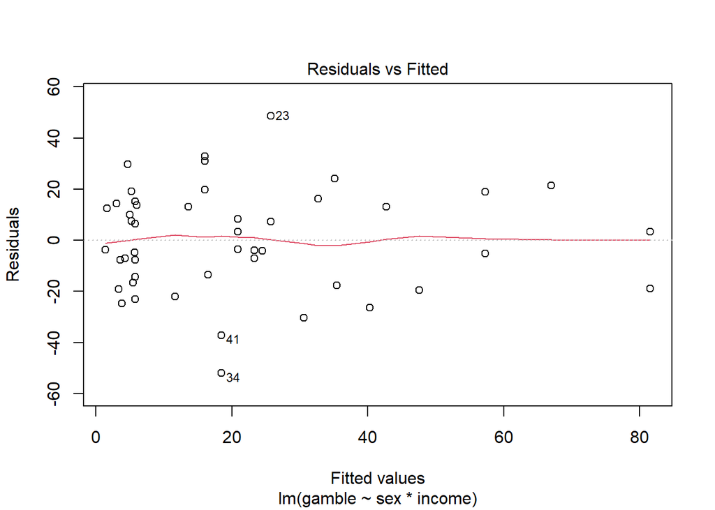

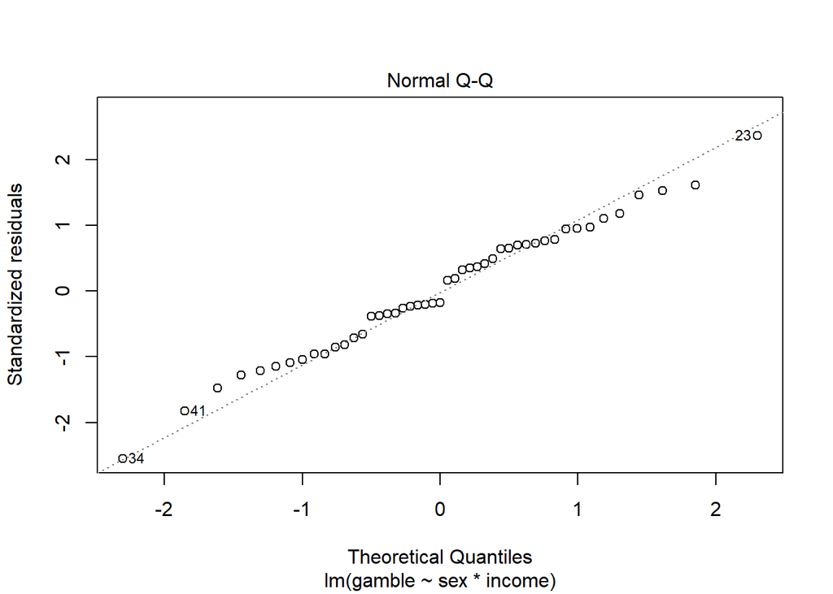

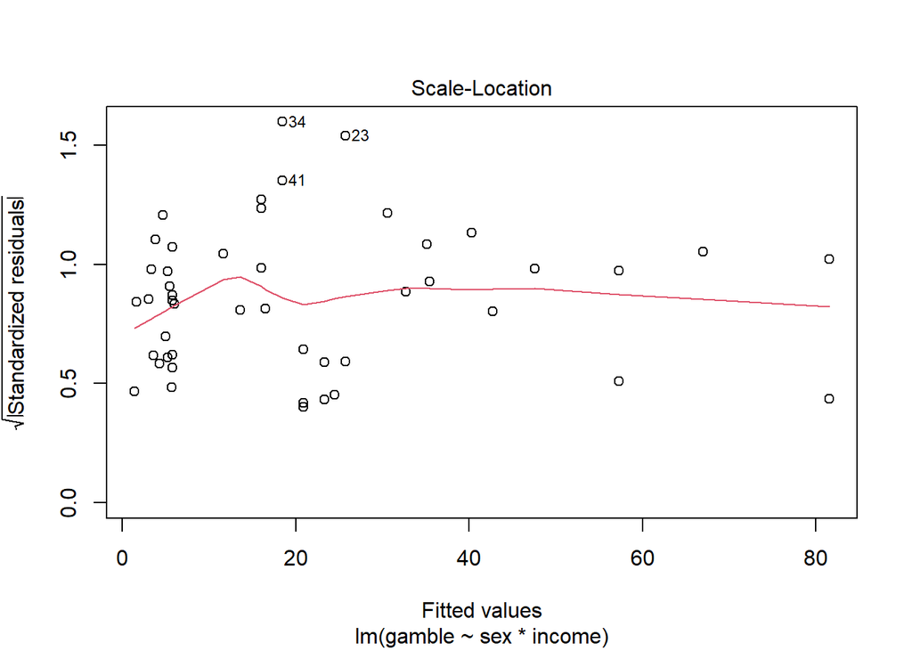

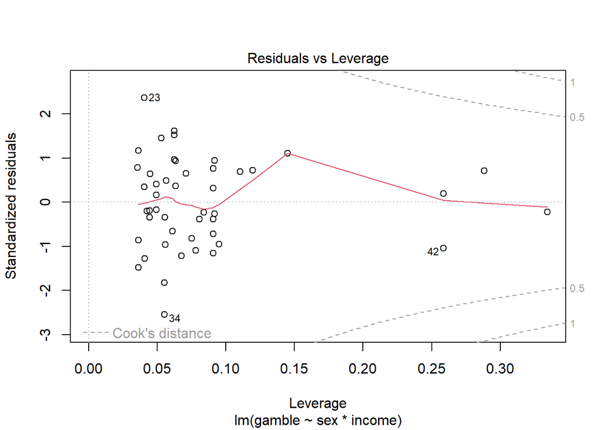

```r
plot(teengamb_lm, ask=FALSE) #evaluación del modelo
```

**¿Es el modelo correcto?:** Si, el modelo es correcto. Para demostrarlo, nos fijamos en las gráficas 1 (Residuals vs. Fitted) y 3 (Scale-Location), y comprobamos que la línea roja central que aparece está en posición horizontal y sin ninguna perturbación muy notable. Como se ve en los gráficos se cumplen las asumciones del ANOVA (normalidad, homocedasticidad y variables independientes); Si esto es así, podemos decir que el modelo es correcto.